# Mummichog Report: data_pos_group2_after_blank_subtraction

mummichog version: 2.2.0-20200207, using metabolic model MFN_1.10.4.

## User input data

User supplied 495 features as reference list.We are using 179 features (p < 0.050000) as significant list. The feature level data are shown in the Manhattan plots below.

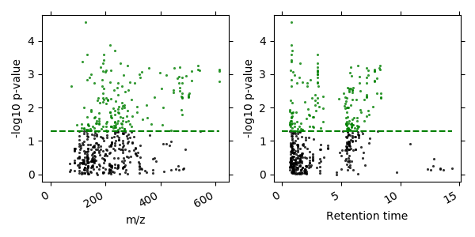

## Top pathways

The reference feature list is mapped to 98 EmpiricalCompounds, significant features to 39 EmpiricalCompounds. In the table below, pathway_size is number of detected EmpiricalCompounds for each pathway; overlap_size is number of significant EmpiricalCompounds. Empirical p-values are estimated by permutation test. Details on EmpiricalCompounds are in 'tables/ListOfEmpiricalCompounds.tsv'.

| Pathways | overlap_size | pathway_size | p-value | overlap_EmpiricalCompounds |
| --- | --- | --- | --- | --- |
| Aspartate and asparagine metabolism | 14 | 25 | 0.00815 | E106,E118,E85,E42,E117,E115,E28,E33,E65,E11,E162,E29,E41,E66 |
| Drug metabolism - cytochrome P450 | 3 | 3 | 0.01059 | E131,E64,E101 |
| Lipoate metabolism | 2 | 2 | 0.03496 | E82,E11 |
| Limonene and pinene degradation | 2 | 2 | 0.03496 | E1,E61 |
| Butanoate metabolism | 5 | 8 | 0.03773 | E134,E8,E32,E145,E66 |

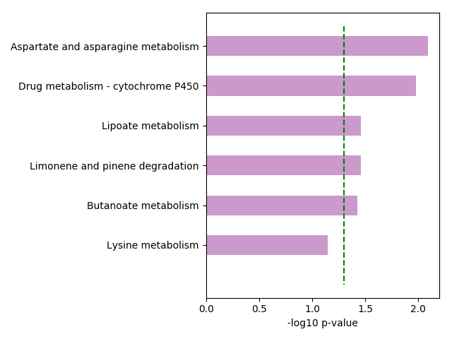

## EmpiricalCompounds favored by above analyses

An EmpiricalCompound is a computational unit for a tentative metabolite. It can group multiple ions, and be any of the isobaric/isomeric species. This table contains EmpiricalCompounds prioritized by pathway/module analysis.

| EmpiricalCompound | Input m/z | Retention time | ion | mz_diff | Statistic | Significant |
| --- | --- | --- | --- | --- | --- | --- |
| E42 | Best guess: C00062, L-Arginine |  | C00792, C00062 |  |  |  |
|  | 175.119255742 | 0.771368181818 | M+H[1+] | 0.0003 | -2.52 | yes |
| E28 | Best guess: CE1938, spermic acid 2 |  | CE1938 |  |  |  |
|  | 233.149851295 | 2.86598981481 | M+H[1+] | 0.0003 | -2.87 | yes |
| E145 | Best guess: C02727, N6-Acetyl-L-lysine |  | C02727 |  |  |  |
|  | 189.123498543 | 1.8932275 | M+H[1+] | 0.0001 | -3.17 | yes |
| E64 | Best guess: C05635, 5-Hydroxyindoleacetate |  | C16596, C05635 |  |  |  |
|  | 192.065716295 | 6.97164509804 | M+H[1+] | 0.0002 | -3.25 | yes |
| E41 | Best guess: C03415, N2-Succinyl-L-ornithine |  | C03415 |  |  |  |
|  | 233.113550285 | 1.43099122807 | M+H[1+] | 0.0004 | -2.1 | no |
|  | 233.113597117 | 1.76603947368 | M+H[1+] | 0.0004 | -1.58 | no |
|  | 255.097476578 | 1.52667395833 | M+Na[1+] | 0.0023 | -4.53 | yes |
| E106 | Best guess: CE1938, spermic acid 2 |  | CE1938 |  |  |  |
|  | 233.149784619 | 3.45851470588 | M+H[1+] | 0.0002 | -2.49 | yes |
| E85 | Best guess: CE5586, dehydrospermidine |  | C00315, CE5586 |  |  |  |
|  | 146.165354973 | 0.642794736842 | M+H[1+] | 0.0002 | -2.91 | yes |
|  | 168.14729468 | 0.699543137255 | M+Na[1+] | 0.0001 | -2.5 | yes |
| E131 | Best guess: C16587, 3-Carbamoyl-2-phenylpropionaldehyde |  | C16595, C16587 |  |  |  |
|  | 216.063360444 | 0.792421568627 | M+Na[1+] | 0.0002 | -5.2 | yes |
| E1 | Best guess: C02452, Perillyl alcohol |  | C02759, C00964, C11409, C02452 |  |  |  |
|  | 175.107838954 | 2.045425 | M+Na[1+] | -0.0015 | -2.59 | yes |
| E65 | Best guess: C03415, N2-Succinyl-L-ornithine |  | C03415 |  |  |  |
|  | 233.113587043 | 2.22401315789 | M+H[1+] | 0.0004 | -2.73 | yes |
| E162 | Best guess: CE1938, spermic acid 2 |  | CE1938 |  |  |  |
|  | 233.149722576 | 5.85605208333 | M+H[1+] | 0.0001 | -2.27 | yes |
| E29 | Best guess: C01110, 5-Amino-2-oxopentanoic acid |  | C00430, C03440, C03341, C01157, C01165, C01110 |  |  |  |
|  | 154.047451052 | 2.30540075758 | M+Na[1+] | -0.0 | -2.3 | yes |
| E8 | Best guess: C02727, N6-Acetyl-L-lysine |  | C02727 |  |  |  |
|  | 189.123474134 | 5.4643975 | M+H[1+] | 0.0001 | -3.3 | yes |
| E101 | Best guess: C16582, 2-Hydroxyfelbamate |  | C16584, C16582 |  |  |  |
|  | 255.097476578 | 1.52667395833 | M+H[1+] | -0.0001 | -4.53 | yes |
| E115 | Best guess: C03740, 5-L-Glutamyl-L-alanine |  | C03740 |  |  |  |
|  | 219.097904389 | 1.04370964912 | M+H[1+] | 0.0004 | -2.32 | yes |
| E82 | Best guess: C00725, Lipoate |  | C02225, C04593, C00725 |  |  |  |
|  | 207.050971985 | 0.735034375 | M+H[1+] | 0.0002 | -3.21 | yes |
| E32 | Best guess: C02727, N6-Acetyl-L-lysine |  | C02727 |  |  |  |
|  | 189.123411203 | 5.17283174603 | M+H[1+] | 0.0 | -3.47 | yes |
| E66 | Best guess: C00217, D-Glutamate |  | C00025, C00302, C05938, C00217 |  |  |  |
|  | 148.06072817 | 2.93435882353 | M+H[1+] | 0.0003 | -0.51 | no |
|  | 148.060738731 | 2.9864 | M+H[1+] | 0.0003 | -4.15 | yes |
| E118 | Best guess: C00049, L-Aspartate |  | C00402, C00049 |  |  |  |
|  | 134.044947959 | 0.788625757576 | M+H[1+] | 0.0002 | -4.85 | yes |
| E117 | Best guess: C00437, N2-Acetyl-L-ornithine |  | C00437 |  |  |  |
|  | 175.107838954 | 2.045425 | M+H[1+] | 0.0002 | -2.59 | yes |
| E134 | Best guess: C02727, N6-Acetyl-L-lysine |  | C02727 |  |  |  |
|  | 189.123400279 | 5.84742142857 | M+H[1+] | 0.0 | -2.3 | yes |
| E11 | Best guess: C00047, L-Lysine |  | C00047 |  |  |  |
|  | 147.113034939 | 0.689177272727 | M+H[1+] | 0.0003 | -2.18 | yes |
| E33 | Best guess: CE1938, spermic acid 2 |  | CE1938 |  |  |  |
|  | 233.149946848 | 0.84665 | M+H[1+] | 0.0004 | -4.99 | yes |
| E61 | Best guess: C02576, Perillyl aldehyde |  | C02576 |  |  |  |
|  | 173.092272313 | 1.2794075 | M+Na[1+] | -0.0015 | -1.6 | no |
|  | 219.097904389 | 1.04370964912 | M+HCOONa[1+] | -0.0013 | -2.32 | yes |

## More data

Full data tables from pathway analysis, module analysis and activity network are stored in the 'tables/' directory. The tsv files can be imported into a spreadsheet program, e.g. MS Excel. Under the 'figures/network_modules/' directory are files intended for Cytoscape (cytoscape.org) visualization. Please refer to Cytoscape's guides for details. Details of this run are recorded in file mummichog.log.txt.